# kdx_guideline

Evan

10/6/2020

## 개요

- 본 수업을 듣는 수강생들을 위해 간단한 튜토리얼을 만들었다.
- 대회는 다음과 같다.
  - 싸이트: [한국데이터거래소](http://lab.kdx.kr/adl/contest/main.php?fbclid=IwAR3zy6t2iutLlbxzqZ25AiVOqMuYmFuiFapfjJ246RWGdoMhBKMHYvv-WwQ)

[figure not shown]

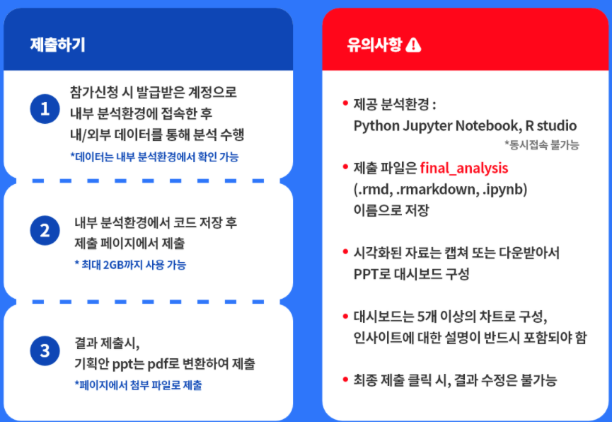

## 1단계 패키지 불러오기

- 데이터 가공 및 시각화 위주의 패키지를 불러온다.

```r
library(tidyverse) # 데이터 가공 및 시각화
library(readxl) # 엑셀파일 불러오기 패키지
```

## 2단계 데이터 불러오기

- 데이터가 많아서 순차적으로 진행하도록 한다.
- 각 데이터에 대한 설명은`활용데이터설명(PDF)`을 참조한다.

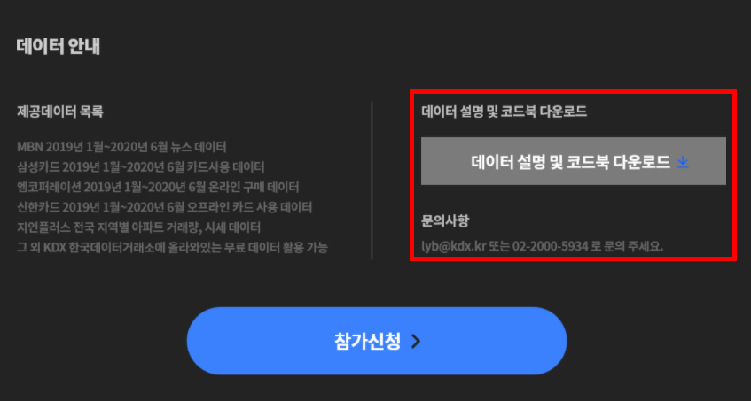

### (1) 삼성카드 데이터

- 우선 삼성카드 데이터를 불러와서 확인한다.
- 한글 파일은 인코딩이 늘 항상 문제다.
  - 파일을 불러오기 전 항상 파일 인코딩을 확인하도록 한다.

```r
readr::guess_encoding("data/Samsungcard.csv", n_max = 100)
```

```
## # A tibble: 2 x 2
##   encoding confidence
##   <chr>         <dbl>
## 1 EUC-KR         1
## 2 GB18030        0.62
```

- Encoding 확인 결과 `EUC-KR`로 확인하였다.

```r
samsung_card <- read_xlsx("data/Samsungcard.xlsx")
samsung_card2 <- read.csv("data/Samsungcard.csv", fileEncoding = "EUC-KR")
```

- 위 두 파일이 동일한 것을 확인해본다

```r
head(samsung_card)
```

```
## # A tibble: 6 x 5
##   소비일자 소비업종  성별  연령대 소비건수
##      <dbl> <chr>     <chr> <chr>     <dbl>
## 1 20190101 가전/가구 남성  20대       5529
## 2 20190101 가전/가구 남성  30대      17536
## 3 20190101 가전/가구 남성  40대      22838
## 4 20190101 가전/가구 남성  50대      15801
## 5 20190101 가전/가구 남성  60대       6772
## 6 20190101 가전/가구 여성  20대       5937
```

```r
head(samsung_card2)
```

```
##   소비일자  소비업종 성별 연령대 소비건수
## 1 20190101 가전/가구 남성   20대     5529
## 2 20190101 가전/가구 남성   30대    17536
## 3 20190101 가전/가구 남성   40대    22838
## 4 20190101 가전/가구 남성   50대    15801
## 5 20190101 가전/가구 남성   60대     6772
## 6 20190101 가전/가구 여성   20대     5937
```

- 두 파일이 동일한 것을 확인하였다면 이제 `samsung_card2`는 삭제를 한다.
  - `RAM`을 아껴 쓰자.

```r
rm(samsung_card2) # 객체 지우는 함수
ls() # 현재 저장된 객체 확인하는 함수
```

```
## [1] "samsung_card"
```

### (2) 신한카드 데이터

- 이번에는 `ShinhanCard.xslx` 데이터를 불러온다.

```r
shinhancard <- read_xlsx("data/Shinhancard.xlsx")
head(shinhancard)
```

```
## # A tibble: 6 x 8
##   일별    성별  연령대별 업종               `카드이용건수(천건)`… ...6  ...7   ...8
##   <chr>   <chr> <chr>    <chr>                           <dbl> <lgl> <lgl> <dbl>
## 1 201901… F     20대     M001_한식                       299.  NA    NA       10
## 2 201901… F     20대     M002_일식/중식/양식…               88.3 NA    NA       NA
## 3 201901… F     20대     M003_제과/커피/패스트푸드…              291.  NA    NA       NA
## 4 201901… F     20대     M004_기타요식                   446.  NA    NA       NA
## 5 201901… F     20대     M005_유흥                        24.2 NA    NA       NA
## 6 201901… F     20대     M006_백화점                      35.3 NA    NA       NA
```

- 위 데이터를 불러오니 불필요한 `6:8` 변수가 불러온 것을 확인할 수 있다.
  - 실제 엑셀 데이터를 열어도 빈값임을 확인할 수 있다.
  - 따라서, `6:8` 변수는 삭제한다.

```r
shinhancard <- shinhancard %>%
  select(-c(6:8))

head(shinhancard)
```

```
## # A tibble: 6 x 5
##   일별     성별  연령대별 업종                      `카드이용건수(천건)`
##   <chr>    <chr> <chr>    <chr>                                    <dbl>
## 1 20190101 F     20대     M001_한식                                299.
## 2 20190101 F     20대     M002_일식/중식/양식                       88.3
## 3 20190101 F     20대     M003_제과/커피/패스트푸드                291.
## 4 20190101 F     20대     M004_기타요식                            446.
## 5 20190101 F     20대     M005_유흥                                 24.2
## 6 20190101 F     20대     M006_백화점                               35.3
```

### (3) 지인플러스

```r
gin_8a <- read_csv("data/GIN00008A.csv")
gin_9a <- read_csv("data/GIN00009A.csv")
```

- 위 두개의 데이터를 확인해본다.

```r
glimpse(gin_8a)
```

```
## Rows: 937,904
## Columns: 9
## $ ym             <dbl> 200601, 200602, 200603, 200604, 200605, 200606, 200607…
## $ area_lvl_scor  <dbl> 0, 0, 0, 0, 0, 0, 0, 0, 0, 0, 0, 0, 0, 0, 0, 0, 0, 0, …
## $ lgdng_cd       <chr> "0000000000", "0000000000", "0000000000", "0000000000"…
## $ trd_cont       <dbl> 23357, 38617, 52241, 44253, 41916, 30257, 28613, 37362…
## $ avg_trd_cont   <dbl> 0, 0, 0, 0, 0, 0, 0, 0, 0, 0, 0, 0, 0, 0, 0, 0, 0, 0, …
## $ trd_deal_rat   <dbl> NA, NA, NA, NA, NA, NA, NA, NA, NA, NA, NA, NA, NA, NA…
## $ mtrnt_cont     <dbl> 0, 0, 0, 0, 0, 0, 0, 0, 0, 0, 0, 0, 0, 0, 0, 0, 0, 0, …
## $ avg_mtrnt_cont <dbl> 0, 0, 0, 0, 0, 0, 0, 0, 0, 0, 0, 0, 0, 0, 0, 0, 0, 0, …
## $ mtrnt_deal_rat <dbl> NA, NA, NA, NA, NA, NA, NA, NA, NA, NA, NA, NA, NA, NA…
```

```r
glimpse(gin_9a)
```

```
## Rows: 785,805
## Columns: 4
## $ lgdng_cd <dbl> 1.1e+09, 1.1e+09, 1.1e+09, 1.1e+09, 1.1e+09, 1.1e+09, 1.1e+0…
## $ std_date <date> 2006-01-21, 2006-02-21, 2006-03-21, 2006-04-21, 2006-05-21,…
## $ trd_prc  <dbl> 1289, 1271, 1291, 1307, 1321, 1335, 1357, 1381, 1411, 1444, …
## $ ldpb_prc <dbl> NA, NA, NA, NA, NA, NA, NA, NA, NA, NA, NA, NA, NA, NA, NA, …
```

### (4) JSON 파일 불러오기

- `JSON` 파일 불러올 때에는 `jsonlite` 패키지를 활용한다.

```r
library(jsonlite)
GIN_10m <- fromJSON("data/center_GIN00010M.json")
glimpse(GIN_10m)
```

```
## Rows: 20,572
## Columns: 8
## $ AREA_LVL_SCOR <int> 1, 2, 3, 3, 3, 3, 3, 3, 3, 3, 3, 3, 3, 3, 3, 3, 3, 3, 3…
## $ LGDNG_CD      <chr> "1100000000", "1111000000", "1111010100", "1111010200",…
## $ CTPV_NM       <chr> "서울특별시", "서울특별시", "서울특별시", "서울특별시", "서울특별시", "서울특별시", "…
## $ CTGG_NM       <chr> NA, "종로구", "종로구", "종로구", "종로구", "종로구", "종로구", "종로구", "종…
## $ EMD_NM        <chr> NA, NA, "청운동", "신교동", "궁정동", "효자동", "창성동", "통의동", "적선동"…
## $ LA            <dbl> 37.52934, 37.58586, 37.58920, 37.58449, 37.58468, 37.58…
## $ LNGT          <dbl> 126.9515, 126.9775, 126.9693, 126.9679, 126.9731, 126.9…
## $ PYN_CN        <chr> "{\"type\": \"Polygon\", \"coordinates\": [[[126.979658…
```

- `PYN_CN`의 값이 조금 다른 것을 확인할 수 있다.
  - 이 부분은 추후 전처리할 때 정리하는 것으로 확인한다.

### (5) SSC_Data

- 이번에는 `Mcorporation`내 폴더 데이터를 올리도록 한다.
- 이번에 파일을 불러올 때는 `readr::read_csv()`를 활용하여 불러온다.

```r
readr::guess_encoding("data/Mcorporation/KDX시각화경진대회_SSC_DATA.csv")
```

```
## # A tibble: 2 x 2
##   encoding confidence
##   <chr>         <dbl>
## 1 EUC-KR         1
## 2 GB18030        0.76
```

```r
ssc_data <- read_csv("data/Mcorporation/KDX시각화경진대회_SSC_DATA.csv", locale = locale("ko", encoding = "EUC-KR"))
glimpse(ssc_data)
```

```
## Rows: 76,580
## Columns: 5
## $ 소비일자 <dbl> 20190101, 20190101, 20190101, 20190101, 20190101, 20190101, 2019…
## $ 소비업종 <chr> "가전/가구", "가전/가구", "가전/가구", "가전/가구", "가전/가구", "가전/가구", "가전/가구", "…
## $ 성별     <chr> "남성", "남성", "남성", "남성", "남성", "여성", "여성", "여성", "여성", "여성", "남…
## $ 연령대   <chr> "20대", "30대", "40대", "50대", "60대", "20대", "30대", "40대", "50대", …
## $ 소비건수 <dbl> 5529, 17536, 22838, 15801, 6772, 5937, 12895, 16896, 14025, 5909…
```

### (6) 다중 엑셀파일 불러오기 예제

- `상품 카데고리 데이터_KDX` 시각화 폴더 내 엑셀 데이터를 확인해본다.

```r
list.files(path = "data/Mcorporation/상품 카테고리 데이터_KDX 시각화 경진대회 Only/")
```

```
##  [1] "PC사무기기.xlsx"             "TV홈시어터.xlsx"
##  [3] "가공식품.xlsx"               "가방지갑잡화.xlsx"
##  [5] "건강관련용품.xlsx"           "건강식품.xlsx"
##  [7] "계절가전.xlsx"               "골프용품.xlsx"
##  [9] "공구류.xlsx"                 "구기.xlsx"
## [11] "국내외여행.xlsx"             "기타 스포츠.xlsx"
## [13] "낚시.xlsx"                   "남성의류.xlsx"
## [15] "노트북.xlsx"                 "농축수산물.xlsx"
## [17] "도서음반DVD.xlsx"            "등산용품.xlsx"
## [19] "메이크업.xlsx"               "문구사무용품.xlsx"
## [21] "미용가전.xlsx"               "반려동물.xlsx"
## [23] "생활가구.xlsx"               "생활가전.xlsx"
## [25] "생활용품.xlsx"               "서비스티켓.xlsx"
## [27] "성인용품.xlsx"               "세탁청소세면.xlsx"
## [29] "수납가구.xlsx"               "수납용품.xlsx"
```

[output cut: 17 more lines]

- 몇가지 파일을 열어본다.

[figure not shown]

- 엑셀 데이터의 변수 등이 동일한 것을 확인할 수 있다.
- 이제 위 데이터를 한꺼번에 불러와서 하나의 데이터셋으로 합친다.
- 검색키워드 `Multiple Excel Files import in R`

```r
files <- list.files(path = "data/Mcorporation/상품 카테고리 데이터_KDX 시각화 경진대회 Only/", pattern = "*.xlsx", full.names = T)

products <- sapply(files, read_excel, simplify=FALSE) %>%
  bind_rows(.id = "id")

glimpse(products)
```

```
## Rows: 1,837,833
## Columns: 8
## $ id         <chr> "data/Mcorporation/상품 카테고리 데이터_KDX 시각화 경ᄌ…
## $ 구매날짜   <dbl> 20190101, 20190101, 20190101, 20190101, 20190101, 20190101, 20…
## $ 카테고리명 <chr> "PC/사무기기", "PC/사무기기", "PC/사무기기", "PC/사무기기", "PC/사무기기", "PC/사무기기…
## $ 고객성별   <chr> "F", "F", "F", "F", "F", "F", "F", "F", "F", "F", "F", "F", "F…
## $ 고객나이   <dbl> 10, 10, 10, 10, 20, 20, 20, 20, 30, 30, 30, 30, 40, 40, 40, 40…
## $ OS유형     <chr> "IOS", "WINDOWS", "안드로이드", "없음", "IOS", "WINDOWS", "안드로이드", …
## $ 구매금액   <dbl> 352443, 84000, 80870, 3700, 27714776, 11414514, 21223319, 4832…
## $ 구매수     <dbl> 13, 1, 8, 1, 381, 60, 252, 41, 240, 75, 423, 19, 58, 110, 436…
```

## 3단계 데이터 시각화

- 데이터 시각화는 변수의 종류에 따른 시각화를 구현한 것이다.
- 시각화 참조자료는 다음에서 작성이 가능하다.
  - [Top 50 ggplot2 Visualizations - The Master List (With Full R Code)](http://r-statistics.co/Top50-Ggplot2-Visualizations-MasterList-R-Code.html)
- 아래 샘플은 필자가 공부하는 형태를 구현한 것이다. 참조하기를 바란다.

### (1) 수치형 변수 ~ 수치형 변수

- 수치형 변수 ~ 수치형 변수 시각화의 대표적인 기법은 산점도(`scatter`) 또는 `correlation`이라 부른다.
  - `scatter` 시각화를 구현한다.

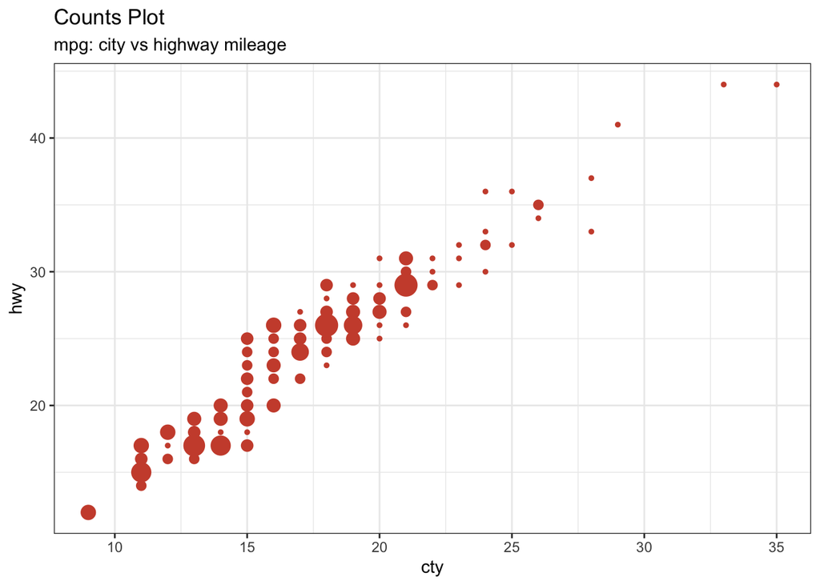

```r
# load package and data
library(ggplot2)
data(mpg, package="ggplot2")
# mpg <- read.csv("http://goo.gl/uEeRGu")

# Scatterplot
theme_set(theme_bw())  # pre-set the bw theme.
g <- ggplot(mpg, aes(cty, hwy))
g + geom_count(col="tomato3", show.legend=F) +
  labs(subtitle="mpg: city vs highway mileage",
       y="hwy",
       x="cty",
       title="Counts Plot")
```

- 위 그래프를 작성한 뒤에는 반드시 데이터의 유형을 확인한다.

```r
class(mpg$cty); class(mpg$hwy)
```

```
## [1] "integer"
```

```
## [1] "integer"
```

- 위 작업을 하는 이유는 현재 내 데이터에서 위 데이터 유형과 비슷한 것인지 확인하기 위한 것이다.
  - 단 산점도를 시각화할 때 유의점이 있다. 데이터가 크기 때문에 시각화 구현에 시간이 소요된다.
  - 이 때 필요한 방법론이 샘플링이다.

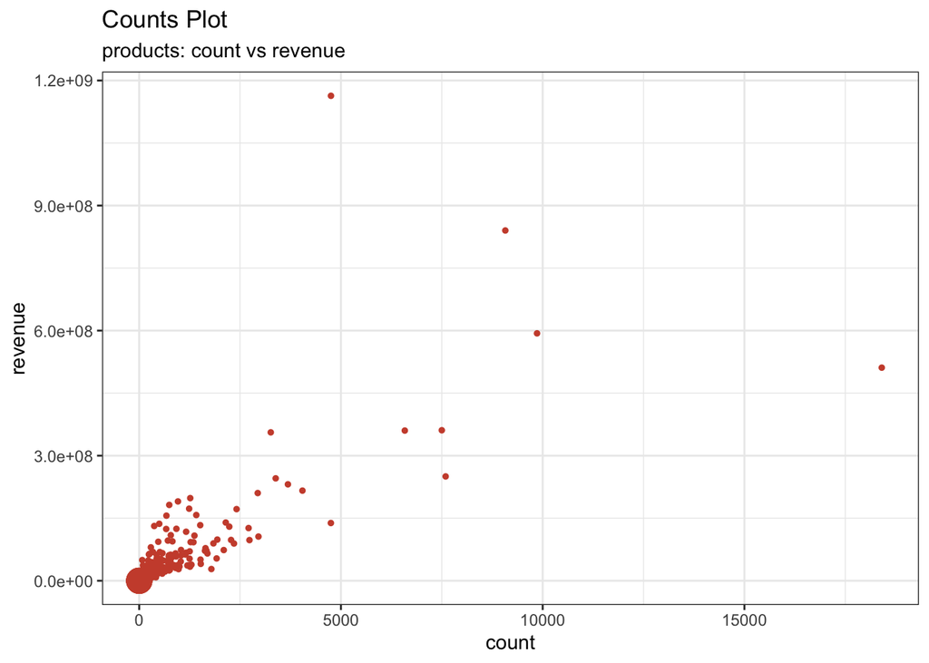

```r
temp_products <- sample_n(products, 1000)
g <- ggplot(temp_products, aes(x = 구매수, y = 구매금액))
g + geom_count(col="tomato3", show.legend=F) +
  labs(subtitle="products: count vs revenue ",
       y="revenue",
       x="count",
       title="Counts Plot")
```

- 분명 동일한 시각화를 작성하였지만, 다르게 나왔다. 이럴 경우에는 `x` + `y`축에 `log Transformation`를 해준다.

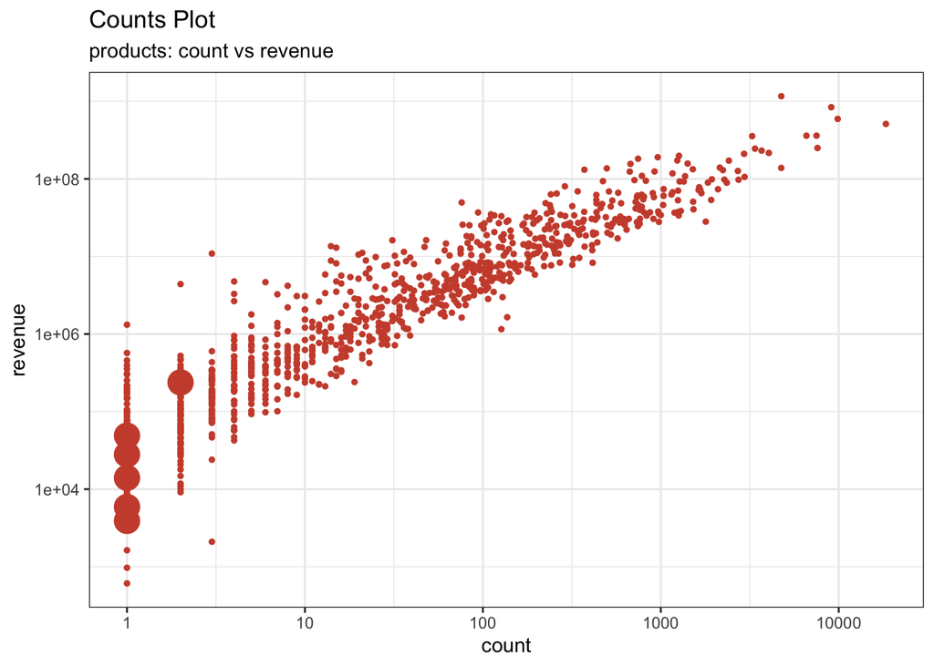

```r
g +
  geom_count(col="tomato3", show.legend=F) +
  scale_x_log10() +
  scale_y_log10() +
  labs(subtitle="products: count vs revenue ",
       y="revenue",
       x="count",
       title="Counts Plot")
```

- 위 그래프를 보고 해석하는 것은 수강생들이 해야 하는 업무이다.

### (2) 범주형 변수 ~ 수치형 변수

- 대표적인 방법으로는 `boxplot`이 있다.
- 그러나, 이번에는 카테고리명 기준으로 평균 구매금액의 평균을 구해본다. - 이번에도 마찬가지로 샘플을 보여준뒤 참조하는 형태로 작성한다.

```r
cty_mpg <- aggregate(mpg$cty, by=list(mpg$manufacturer), FUN=mean)
colnames(cty_mpg) <- c("make", "mileage")
cty_mpg <- cty_mpg[order(cty_mpg$mileage), ]
cty_mpg$make <- factor(cty_mpg$make, levels = cty_mpg$make)
head(cty_mpg, 4)
```

```
##          make  mileage
## 9     lincoln 11.33333
## 8  land rover 11.50000
## 3       dodge 13.13514
## 10    mercury 13.25000
```

- 이렇게 정렬한 것을 시각화로 구현하는 것이다.

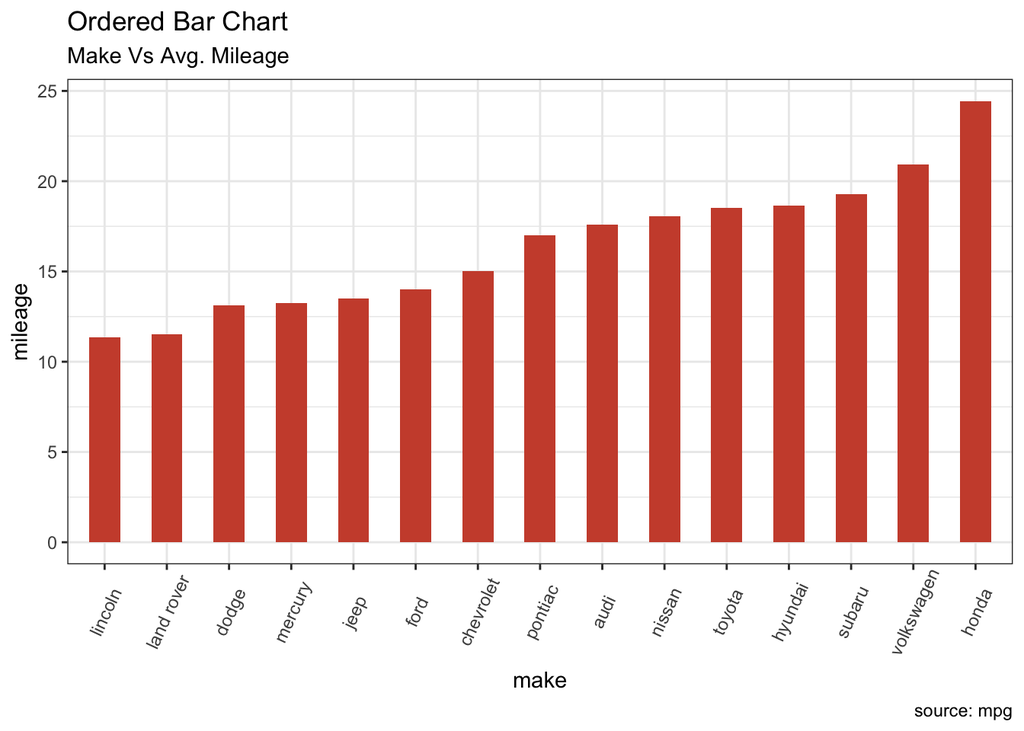

```r
library(ggplot2)
theme_set(theme_bw())

# Draw plot
ggplot(cty_mpg, aes(x=make, y=mileage)) +
  geom_bar(stat="identity", width=.5, fill="tomato3") +
  labs(title="Ordered Bar Chart",
       subtitle="Make Vs Avg. Mileage",
       caption="source: mpg") +
  theme(axis.text.x = element_text(angle=65, vjust=0.6))
```

- 이제 내 데이터에 확인해보자.

```r
cat_rev <- aggregate(products$카테고리명, by=list(products$구매금액), FUN=mean)
```

- 위 코드를 실행하면 속도가 굉장히 더딘 것을 확인할 수 있다.
- 실제로 `aggregate()` 함수는 오래 걸린다.
  - 그래서 `dplyr`를 활용하여 피벗테이블을 만든다.

```r
library(ggplot2)

# 맥 유저만 아래 코드 적용
theme_set(theme_classic(base_family='NanumGothic'))

cat_rev <- products %>%
  group_by(카테고리명) %>%
  summarise(mean = mean(구매금액)) %>%
  arrange(desc(mean))

cat_rev <- cat_rev[order(cat_rev$mean, decreasing = TRUE), ]  # sort
cat_rev$카테고리명 <- factor(cat_rev$카테고리명, levels = cat_rev$카테고리명)  # to retain the order in plot.

head(cat_rev)
```

```
## # A tibble: 6 x 2
##   카테고리명         mean
##   <fct>             <dbl>
## 1 도서/음반/DVD 93366896.
## 2 서비스/티켓   89818959.
## 3 여성의류      62282167.
## 4 신발          58230514.
## 5 가공식품      48249770.
## 6 PC/사무기기   30909343.
```

- 이제 위 데이터를 시각화 해본다.

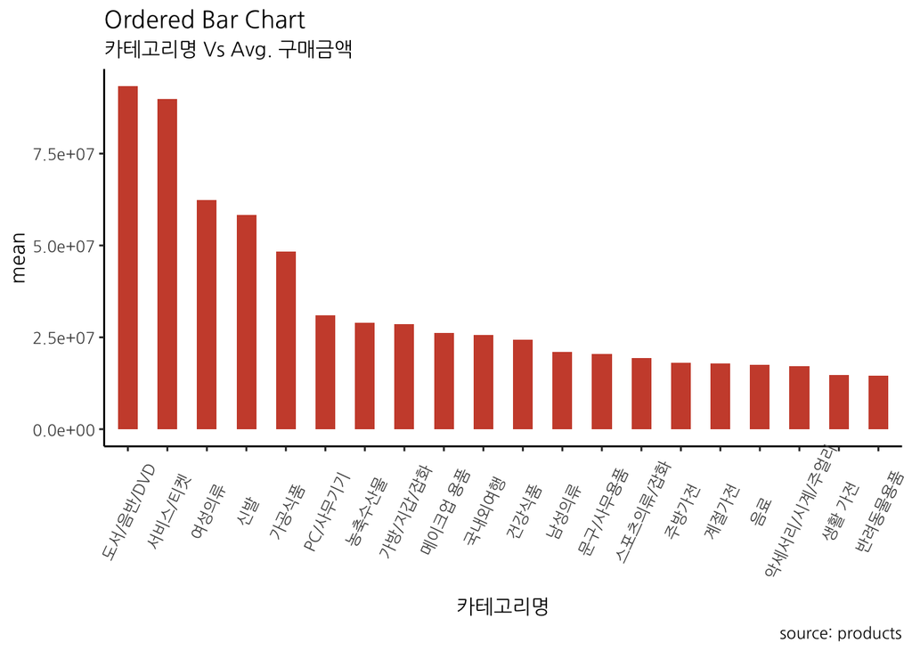

```r
ggplot(cat_rev %>% head(20), aes(x = 카테고리명, y = mean)) +
  geom_bar(stat="identity", width=.5, fill="tomato3") +
  theme(axis.text.x = element_text(angle=65, vjust=0.6)) +
  labs(title="Ordered Bar Chart",
       subtitle="카테고리명 Vs Avg. 구매금액",
       caption="source: products")
```

### (3) 위 두 그래프 확장하기

- 성별 및 연령대별로 추가적인 변수를 넣어 확인해보는 시각화를 만들어 본다.